# CMSC320 Final Project (Covid-19)

Luobin Chen, Yufei Zhang

Loading and Plotting Data

We find the data from Kaggle (https://www.kaggle.com/imdevskp/corona-virus-report?select=covid_19_clean_complete.csv). Now, We download the data and perform some simple plots to analyze the data. The first step is extracting the csv file then passing that to our data frame. Since we want to use the data for nucleic acids test(NAT) for further analysis, we download the data test.csv from Kaggle. (https://www.kaggle.com/imdevskp/corona-virus-report?select=tests.csv) We read the file using read_csv after importing essential library “tidyverse”. We renamed “Country/Region” to “Region” and “Province/States” to “States” to be easier to reference.

```r
library(tidyverse)
df <- read_csv("covid_19_clean_complete.csv")
names(df)[1] <- "State"
names(df)[2] <- "Region"
head(df)
```

```
## # A tibble: 6 x 8
##   State Region                Lat   Long Date    Confirmed Deaths Recovered
##   <chr> <chr>               <dbl>  <dbl> <chr>       <dbl>  <dbl>     <dbl>
## 1 <NA>  Afghanistan          33    65    1/22/20         0      0         0
## 2 <NA>  Albania              41.2  20.2  1/22/20         0      0         0
## 3 <NA>  Algeria              28.0   1.66 1/22/20         0      0         0
## 4 <NA>  Andorra              42.5   1.52 1/22/20         0      0         0
## 5 <NA>  Angola              -11.2  17.9  1/22/20         0      0         0
## 6 <NA>  Antigua and Barbuda  17.1 -61.8  1/22/20         0      0         0
```

```r
test <- read_csv("tests.csv")
head(test)
```

```
## # A tibble: 6 x 5
##   Country `Cases per 1M pop` `Deaths per 1M pop` `Total Tests` `Tests per 1M po…
##   <chr>                <dbl>               <dbl>         <dbl>             <dbl>
## 1 USA                   4256                 252       9935720             30017
## 2 Spain                 5765                 576       2467761             52781
## 3 Russia                1591                  14       5805404             39781
## 4 UK                    3336                 482       2007146             29566
## 5 Italy                 3659                 511       2673655             44221
## 6 France                2730                 414       1384633             21213
```

Now we have two essential data set for our analysis. First data set “df” has the information of confirmed cases, deaths, and recovered cases for every countries over the world from 1/22/20 to 5/09/2020. Additionally, it includes lat and long attributes for our interaction visualization. Second data set “test” has the information of ratio of confirmed cases, deaths, and NAT per 1 million population for each country.

Now let’s make some plot to have a general view of the data set. Initially, we want to plot all the confirmed cases for each country until 5/9/2020. However, because of a large amount of data, we can’t plot all the region attribute as color. There are too many data points which will make the x and y axis hard to see and analyze. Therefore, we first use arrange to sort data points by their confirmed cases. Then, we use slice command to slice out the top 15 countries that have the highest number of confirmed cases. We use group_by and sum command to get confirmed case for different regions/countries. The ungroup command is necessary for arrange command. We create a new data frame called “confirmed” which contains the information for the top 15 countries on the purpose of making the plot.

The ggplot command helps us to make the plot. The data is from the first data set “df”. Here we map the Region attribute to the x position in the plot and the Confirmed_cases_for_country attribute to the y position in the plot. The ggplot contains the aes call. Here we choose points as the geometric representations of our chosen graphical characteristics using the geom_point function.

```r
# Confirmed case for top 20
confirmed <-  df %>%
  filter(Date=="5/9/20") %>%
  group_by(Region) %>%
  mutate(Confirmed_cases_for_country=sum(Confirmed)) %>%
  ungroup(Region) %>%
  arrange(desc(Confirmed_cases_for_country))


confirmed <- unique(data.frame(Region=confirmed$Region,Confirmed_cases_for_country=confirmed$Confirmed_cases_for_country))

confirmed
```

```
##                               Region Confirmed_cases_for_country
## 1                                 US                     1309550
## 2                              Spain                      223578
## 3                              Italy                      218268
## 4                     United Kingdom                      216525
## 15                            Russia                      198676
## 16                            France                      176782
## 27                           Germany                      171324
## 28                            Brazil                      156061
## 29                            Turkey                      137115
## 30                              Iran                      106220
## 31                             China                       83990
## 64                            Canada                       68918
## 78                              Peru                       65015
## 79                             India                       62808
```

[output cut: 173 more lines]

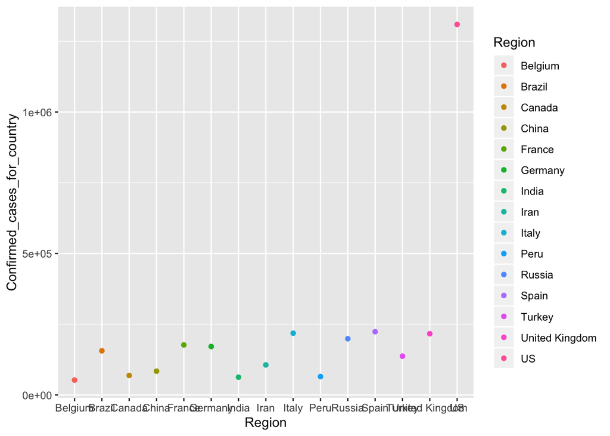

```r
confirmed %>%
  slice(1:15) %>%
  ggplot(mapping=aes(y=Confirmed_cases_for_country,x=Region,color=Region)) +
  geom_point()
```

From the plot, we can see the top 15 countries that have the highest number of confirmed cases clearly. They are US, Spain, Italy, United Kingdom, Russia, France, Germany, Brazil, Turkey, Iran, China, Canada, Peru, India, Belgium. We can see from the plot that the rate of confirmed cases in the United States is much higher than in other countries.

Now, we want to take advantage of the interaction visualization to make a more intuitive graph. We use the data form our data set “df”. We select all the data points from the last date which is 5/9/20. We use Leaflet library to generate the graph for each states or provinces.

We learned from this website https://rstudio.github.io/leaflet/markers.html to generate useful icons. Base on our condition, states with less than 10000 confirmed cases have green popup icons. States with less than 50000 confirmed cases have orange popup icons. States will more than 50000 confirmed cases have red popup icons. These icons give us a better understanding of the distribution of corona virus. Additionally, it’s easier to see which area has the highest number of confirmed cases.

```r
df <- df %>%
  filter(Date=="5/9/20")

head(df)
```

```
## # A tibble: 6 x 8
##   State Region                Lat   Long Date   Confirmed Deaths Recovered
##   <chr> <chr>               <dbl>  <dbl> <chr>      <dbl>  <dbl>     <dbl>
## 1 <NA>  Afghanistan          33    65    5/9/20      4033    115       502
## 2 <NA>  Albania              41.2  20.2  5/9/20       856     31       627
## 3 <NA>  Algeria              28.0   1.66 5/9/20      5558    494      2546
## 4 <NA>  Andorra              42.5   1.52 5/9/20       754     48       545
## 5 <NA>  Angola              -11.2  17.9  5/9/20        43      2        13
## 6 <NA>  Antigua and Barbuda  17.1 -61.8  5/9/20        25      3        19
```

```r
library(leaflet)
getColor <- function(df) {
  sapply(df$Confirmed, function(Confirmed) {
  if(Confirmed <= 10000) {
    "green"
  } else if(Confirmed <= 50000) {
    "orange"
  } else {
    "red"
  } })
}


icons <- awesomeIcons(
  icon = 'ios-close',
  iconColor = 'black',
  library = 'ion',
  markerColor = getColor(df)
)

map <- leaflet(df) %>%
  addTiles() %>%
  addAwesomeMarkers(~Long,~Lat,popup=~as.character(Confirmed),icon=icons,label=~as.character(Confirmed))

map
```

[interactive chart not shown]

Now let’s look at our second data set. Initially, we want to ask if tests is enough for each country. Does confirmed cases affected by the number of tests? Is there any people with symptoms in the country still haven’t recieve test?

If the ratio is very small, it’s good. This means we have enough test to examine more people in the country. However, if the ration is very large, it means that it’s possible there are still a lot of people who haven’t been tested. We select top 50 countries which has large ratio. Base on ratio, we can conclude that countries which has ratio larger than 0.1 don’t have enough NAT.

```r
names(test)[2] <- "Cases_per_1M_pop"
names(test)[3] <- "Deaths_per_1M_pop"
names(test)[4] <- "Total_Tests"
names(test)[5] <- "Tests_per_1M_pop"

test %>%
  mutate(ratio=Cases_per_1M_pop/Tests_per_1M_pop)  %>%
  arrange(desc(ratio)) %>%
  slice(1:50)
```

```
## # A tibble: 50 x 6
##    Country  Cases_per_1M_pop Deaths_per_1M_p… Total_Tests Tests_per_1M_pop ratio
##    <chr>               <dbl>            <dbl>       <dbl>            <dbl> <dbl>
##  1 Sao Tom…              949             23           175              799 1.19
##  2 Algeria               138             12          6500              148 0.932
##  3 Guinea-…              417              2          1500              762 0.547
##  4 Equator…              313              3           854              609 0.514
##  5 Yemen                   2              0.3         120                4 0.5
##  6 Andorra              9810            621          1673            21653 0.453
##  7 Bolivia               254             11          7651              655 0.388
##  8 Honduras              210             12          5653              571 0.368
##  9 Ecuador              1724            132         85223             4830 0.357
## 10 Cabo Ve…              480              4           791             1423 0.337
## # … with 40 more rows
```